# Metody Nieparametryczne z R - Projekt zaliczeniowy

Patryk Zieliński

7 lutego 2019

## Wprowadzenie

Celem projektu jest budowa modelu liniowego z wykorzystaniem metod ekonometrycznych oraz metod bootstrapowych dla spalania w danych dotyczących samochodów osobowych z pliku cars.csv. Pierwotne dane były zapisane w jednostkach używanych w krajach anglojęzycznych, tj. USA czy Anglia, dlatego konieczne było konieczne ich przekształcenie do jednostek używanych w Polsce.

## Opis danych

Dane wykorzystane w projekcie obejmują 9 zmiennych przedstawionych poniżej:

- Spalanie - wyrażone w litrach na 100km
- NazwaSamochodu
- LiczbaCylindrow
- Moc - wyrażona w koniach mechanicznych
- WiekSamochodu - liczba lat, która minęła od wyprodukowania samochodu
- MiejsceProdukcji
- ObjetoscSilnika - wyrażona w litrach
- Waga - wyrażona w kilogramach
- CzasPrzyspieszenia - okres czasu (w sekundach) potrzebny do osiągnięcia prędkości 100km na godzinę przez dany samochód

## Hipotezy badawcze

1. Badane modele samochodów posiadają podobne czasy przyspieszenia do 100 kilometrów na godzinę.
2. W całym rozpatrywanym okresie (lata 1970 - 1982) produkowano pojazdy o podobnej mocy silnika.
3. Najwięcej samochodów zostało wyprodukowanych w USA.
4. Objętość silnika ma wpływ na spalanie paliwa.

## Analiza opisowa

W poniższej tabeli przedstawiono pdostawowe statystyki opisowe dla zmiennych poddanych analizie:

```
##                     Srednia Odchylenie Standardowe Mediana Minimum
## LiczbaCylindrow       5.490                  1.711    4.00    3.00
## Moc                 104.599                 38.148   95.00   46.00
## Spalanie             11.219                  3.913   10.20    5.00
## ObjetoscSilnika       3.885                  2.100    3.02    1.36
## Waga               1349.131                389.902 1270.50  732.00
## CzasPrzyspieszenia   16.042                  2.832   16.10    8.30
## WiekSamochodu        43.016                  3.628   43.00   37.00
##                    Maksimum Skośność Kurtoza Współczynnik zmienności
## LiczbaCylindrow         8.0    0.487  -1.428                   0.312
## Moc                   230.0    1.018   0.491                   0.365
## Spalanie               26.1    0.750   0.044                   0.349
## ObjetoscSilnika         9.1    0.667  -0.864                   0.541
## Waga                 2331.0    0.472  -0.914                   0.289
## CzasPrzyspieszenia     24.5    0.174   0.171                   0.177
## WiekSamochodu          49.0    0.008  -1.116                   0.084
```

Skośność jest miarą asymetrii, która informuje, czy w analizowanym zbiorze danych występuje większa liczba o wartościach większych od średniej, czy mniejszych od średniej arytmetycznej. Dla wartości współczynnika skośności mniejszych od 0 występuje asymetria lewostronna, dla wartości dodatnich- prawostronna. W przypadku analizowanych danych dotyczących samochodów wszystkie zmienne charakteryzują się asymetrią prawostronną ze względu na dodatnie wartości współczynnika skośności. Jedynie dla zmiennej WiekSamochodu wartość ta jest bliska zera, co może świadczyć że rozkład tej zmiennej jest podobny do rozkładu normalnego.

Kurtoza jest miarą koncentracji wyników, informującą o koncentracji wyników wokół średniej arytmetycznej. Dla zmiennych LiczbaCylindrow, ObjetoscSilnika, Waga oraz WiekSamochodu występuje ujemna kurtoza, co świadczy, że w zbiorze danej cechy można zaobserwować większą liczbę wyników skrajnych, tzn. bardziej oddalonych od średniej. W przypadku zmiennych Moc, Spalanie i CzasPrzyspieszenia wartości cechy znajdują się bliżej średniej arytmetycznej.

Współczynnik zmienności to miara zróżnicowania zmiennych, wyrażona w procentach. Podczas selekcji zmiennych do modelu najczęściej uwzględnia się tylko te zmienne, dla których wartość współczynnika jest większa niż ok. 10%. Pomimo tego, że zmienna WiekSamochodu cechuje się zmiennością na poziomie 8,5%, nie zostanie ona usunięta ze względu na słabą korelację ze zmiennymi objaśniającymi.

## Macierz korelacji

Macierz korelacji analizowanych zmiennych przedstawiono na poniższym wykresie:

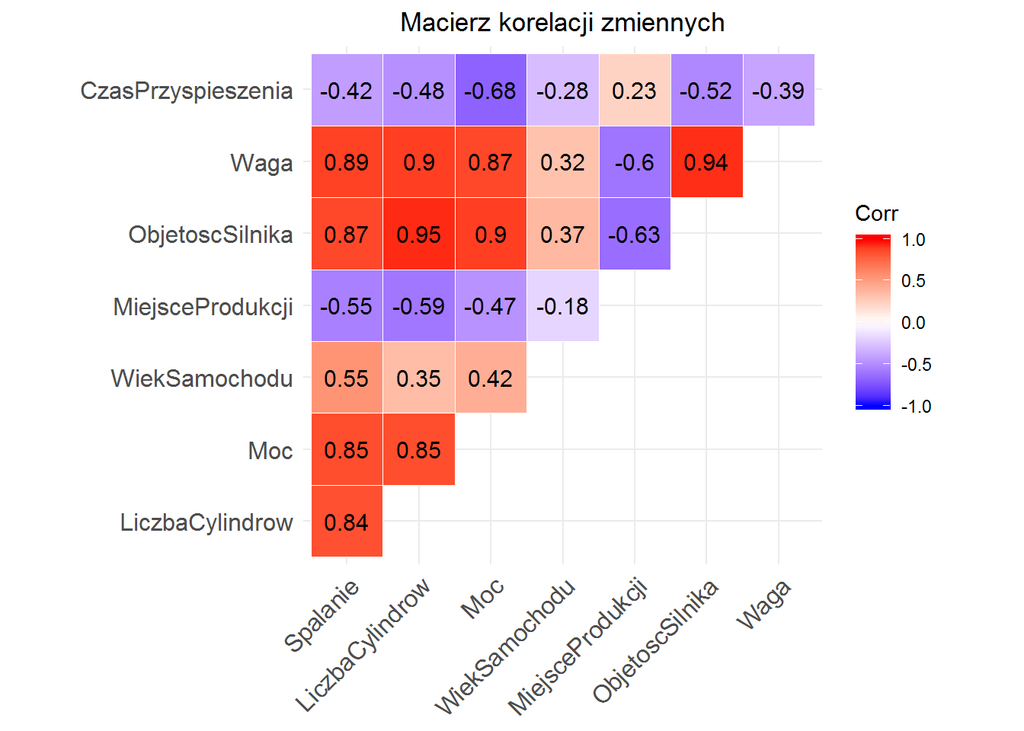

Zmienne objaśniające wchodzące w skład modelu powinny być nieskorelowane między sobą, jednak powinny być silnie skorelowane ze zmienną objaśnianą. Można zaobserwować, że 4 zmienne objaśniające (LiczbaCylindrow, Moc, ObjetoscSilnika, Waga) są silnie skorelowane ze zmienną Spalanie, co w tym przypadku jest pożądaną cechą. Jednak zmienne Waga i LiczbaCylindrow są również silnie skorelowane z niektórymi zmiennymi objaśniającymi, dlatego te dwie zmienne zostają wykluczone z dalszej analizy.

Dla wyznaczonej macierzy korelacji przeprowadzono także test istotności współczynnika korelacji. Pozwala on zweryfikować następujące hipotezy:

H0: korelacja pomiędzy dwoma cechami jest istotna

H1: korelacja pomiędzy dwoma cechami jest nieistotna

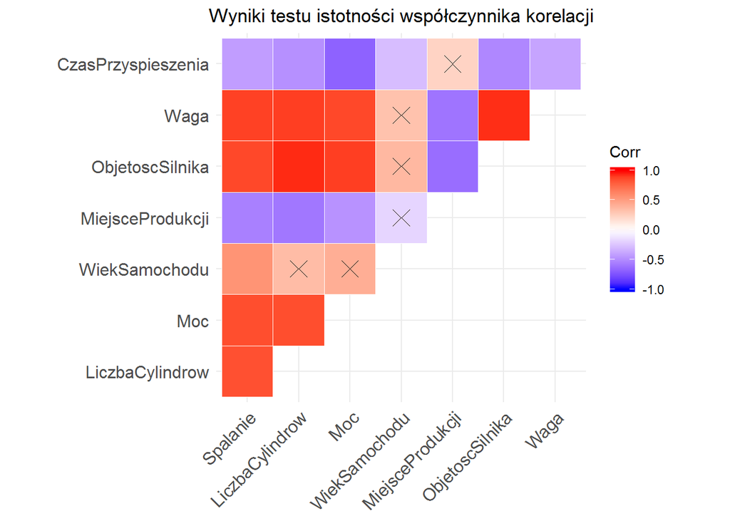

## Analiza wizualna

Na pierwszym wykresie przedstawiono histogram pokazujący rozkład czasu przyspieszenia samochodów. Można zauważyć, że najwięcej samochodów osiąga prędkość 100 kilometrów na godzinę w około 15 sekund (niewiele ponad 50 pojazdów) oraz w czasie 17 sekund (około 45 pojazdów). Bardzo mało jest natomiast samochodów, dla których czas przyspieszenia wynosi mniej niż 10 sekund.

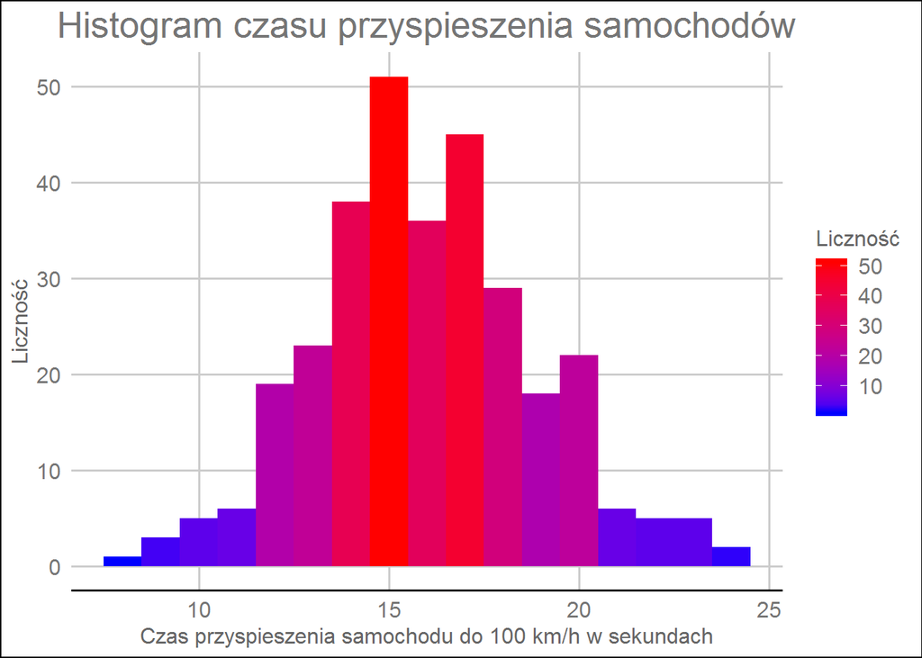

Drugim elementem analizy wizualnej jest sprawdzenie zmiany mocy silnika w produkowanych na przestrzeni lat samochodach. Na potrzebny tego wykresu moc silnika podzielono na dwie grupy: poniżej średniej i powyżej średniej wartości. Poniższy histogram przedstawia to rozróżnienie. Można zobaczyć, że z biegiem lat zwiększała się liczba produkowanych samochodów o mniejszej mocy silnika.

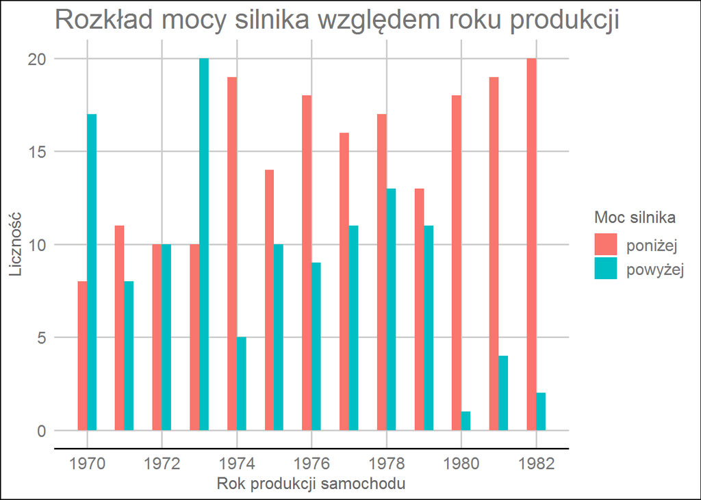

Trzeci wykres przedstawia liczbę produkowanych samochodów w każdym z miejsc na przestrzeni lat. Najwięcej samochodów zostało wyprodukowanych w USA. Gwałtowny spadek produkcji w 1980 mógł być spowodowany wystąpieniem w tym roku kryzysu naftowego - ceny ropy wzrosły do 30 USD za baryłkę, przez co przemysł motoryzacyjny stał się bardzo kosztowny.

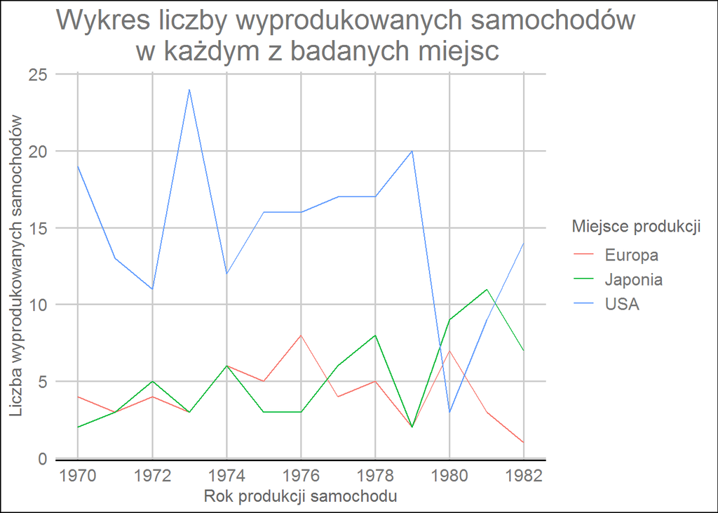

Czwarty wykres przedstawia wykres rozrzutu spalania w zależności od objętości silnika z rozróżnieniem na miejsce produkcji samochodu. Można zaobserwować, że samochody z silnikami o najmniejszej pojemności oraz o najmniejszym spalaniu produkowane są w Japonii, natomiast największe w USA.

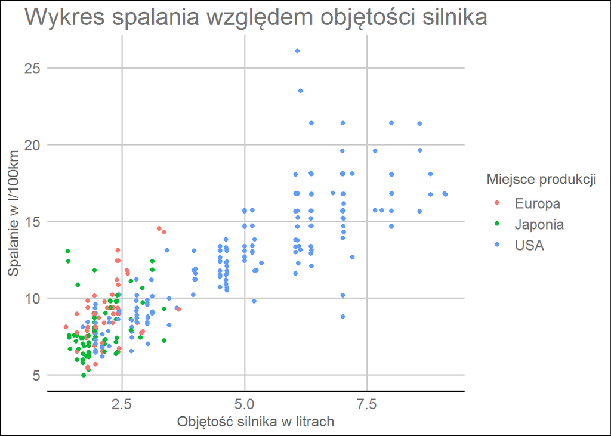

## Budowa modelu liniowego

W pierwszym kroku budowy modelu liniowego wyestymowano model uwzględniający wszystkie zmienne, które nie zostały wykluczone podczas wcześniejszej analizy. Charakterystykę pierwszego modelu regresji przedstawiono poniżej:

```
##
## Call:
## lm(formula = Spalanie ~ Moc + WiekSamochodu + MiejsceProdukcji +
##     ObjetoscSilnika + CzasPrzyspieszenia, data = CarsPL)
##
## Residuals:
##     Min      1Q  Median      3Q     Max
## -5.3620 -0.7923 -0.0303  0.6773  5.7796
##
## Coefficients:
##                      Estimate Std. Error t value Pr(>|t|)
## (Intercept)        -12.542333   1.404139  -8.932  < 2e-16 ***
## Moc                  0.055666   0.006189   8.995  < 2e-16 ***
## WiekSamochodu        0.253333   0.025675   9.867  < 2e-16 ***
## MiejsceProdukcji    -0.322772   0.138043  -2.338     0.02 *
## ObjetoscSilnika      0.684519   0.109205   6.268 1.23e-09 ***
## CzasPrzyspieszenia   0.305564   0.041737   7.321 2.16e-12 ***
## ---
## Signif. codes:  0 '***' 0.001 '**' 0.01 '*' 0.05 '.' 0.1 ' ' 1
##
## Residual standard error: 1.492 on 308 degrees of freedom
## Multiple R-squared:  0.8568, Adjusted R-squared:  0.8545
## F-statistic: 368.7 on 5 and 308 DF,  p-value: < 2.2e-16
```

Pierwszym elementem diagnostyki modelu było wyznaczenie 95% przedziałów ufności dla parametrów oraz ich błędów szacunku. Te wyniki w dalszej części projektu zostaną porównanie z wynikami otrzymanymi poprzez metody bootstrapowe.

```
##                           2.5 %      97.5 %
## (Intercept)        -15.30525266 -9.77941362
## Moc                  0.04348853  0.06784301
## WiekSamochodu        0.20281209  0.30385361
## MiejsceProdukcji    -0.59439790 -0.05114595
## ObjetoscSilnika      0.46963626  0.89940198
## CzasPrzyspieszenia   0.22343792  0.38768983
```

```
##        (Intercept)                Moc      WiekSamochodu
##        1.404139416        0.006188579        0.025675082
##   MiejsceProdukcji    ObjetoscSilnika CzasPrzyspieszenia
##        0.138042654        0.109205314        0.041737115
```

Otrzymany model zawiera wyłącznie istotne zmienne - wartości p-value w teście t-Studenta są mniejsze niż 0,05. Dodatkowo, wszystkie zmienne objaśniające razem są istotne - wartość p-value w teście F jest mniejsza niż 0,05.

Rozpatrywany model wyjaśnia 85,68% zmienności zmiennej objaśnianej. Dodatkowo, nie jest on przeparametryzowany - różnica pomiędzy wartością współczynnika determinacji a skorygowanym współczynnikiem jest mniejsza niż 0,05.

W ramach analizy reszt stworzono wykresy:

- kwantyl-kwantyl
- histogram z dopasowaną funkcją gęstości reszt

oraz przeprowadzono 3 testy na normalność rozkładu:

- Jarque-Bera
- Lillieforsa
- Shapiro-Wilka

W każdym z trzech testów układ hipotez jest taki sam, tzn.:

H0: reszty pochodzą z rozkładu normalnego

H1: reszty nie pochodzą z rozkładu normalnego

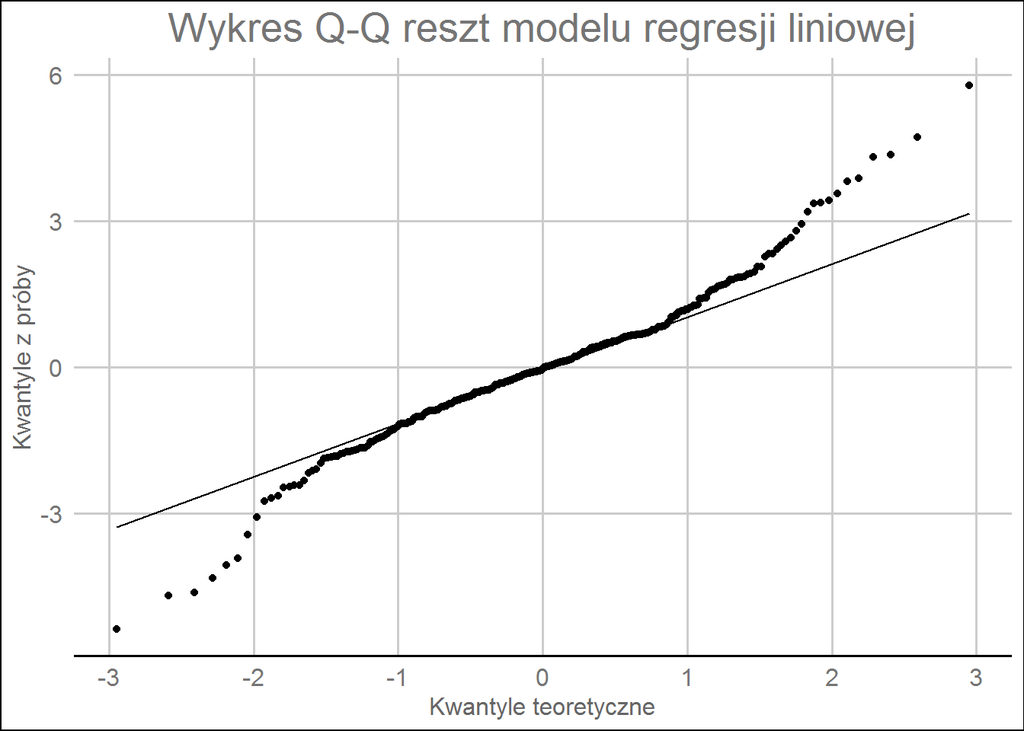

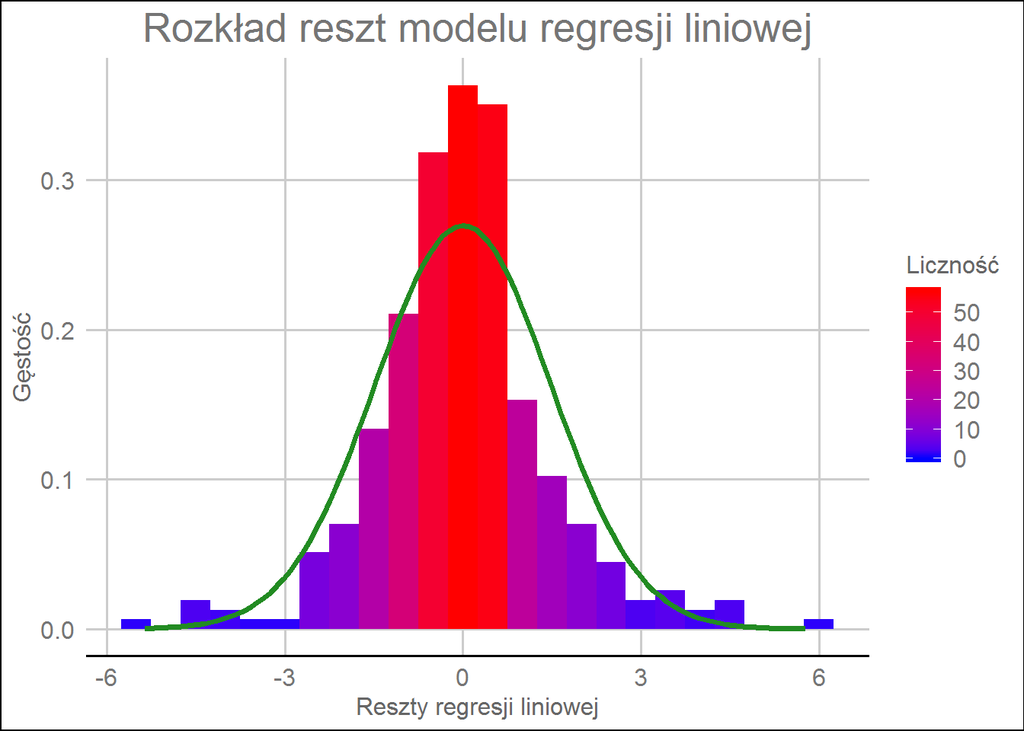

```
##
##  Jarque-Bera test for normality
##
## data:  ResztyRegresjiLiniowej
## JB = 55.049, p-value = 5e-04
```

```
##
##  Lilliefors (Kolmogorov-Smirnov) normality test
##
## data:  ResztyRegresjiLiniowej
## D = 0.085471, p-value = 8.991e-06
```

```
##
##  Shapiro-Wilk normality test
##
## data:  ResztyRegresjiLiniowej
## W = 0.96712, p-value = 1.472e-06
```

Zarówno na podstawie wykresu Q-Q oraz histogramu reszt nie można twierdzić, że reszty posiadają rozkład normalny. Przeprowadzone testy na normalność tylko to potwierdziły - w każdym przypadku wartość p-value jest mniejsza niż 0,05. Na tej podstawie odrzucono hipotezę zerową i podjęto działania mające na celu transformację modelu.

## Regresja liniowa z wykorzystaniem metody Hellwiga

Z racji braku normalności reszt w pierwotnym modelu pierwszą próbą transformacji było dobranie zmiennych za pomocą metody Hellwiga. Do modelu zostały dobrane zmienne: Moc, WiekSamochodu oraz ObjetoscSilnika. Dla tej kombinacji wartość integralnego wskaźnika pojemności informacyjnej była największa i wynosiła 0,817. Rezultaty estymacji drugiego modelu regresji przedstawiono poniżej:

```
##
## Call:
## lm(formula = Spalanie ~ Moc + WiekSamochodu + ObjetoscSilnika,
##     data = CarsPL)
##
## Residuals:
##     Min      1Q  Median      3Q     Max
## -4.9349 -0.8094 -0.1808  0.8094  8.6585
##
## Coefficients:
##                  Estimate Std. Error t value Pr(>|t|)
## (Intercept)     -6.551002   1.122990  -5.834 1.36e-08 ***
## Moc              0.028648   0.005549   5.163 4.36e-07 ***
## WiekSamochodu    0.254261   0.027952   9.096  < 2e-16 ***
## ObjetoscSilnika  0.987618   0.098513  10.025  < 2e-16 ***
## ---
## Signif. codes:  0 '***' 0.001 '**' 0.01 '*' 0.05 '.' 0.1 ' ' 1
##
## Residual standard error: 1.625 on 310 degrees of freedom
## Multiple R-squared:  0.8291, Adjusted R-squared:  0.8275
## F-statistic: 501.4 on 3 and 310 DF,  p-value: < 2.2e-16
```

Podobnie, jak w przypadku pierwszego modelu, wyznaczono 95% przedziały ufności dla parametrów i błędy szacunku przedstawione poniżej:

```
##                       2.5 %      97.5 %
## (Intercept)     -8.76064911 -4.34135485
## Moc              0.01772906  0.03956672
## WiekSamochodu    0.19926115  0.30925995
## ObjetoscSilnika  0.79377983  1.18145571
```

```
##     (Intercept)             Moc   WiekSamochodu ObjetoscSilnika
##     1.122990217     0.005549182     0.027951878     0.098512613
```

Model, w którym zmienne dobrano za pomocą metody Hellwiga, zawiera istotne zmienne objaśniające - zarówno razem, jak i każda z osobna. W tym modelu (porównując z pierwszym modelem) mniejsza część zmienności zmiennej zależnej jest wyjaśniana przez model - 82,91%. Model ten nie jest przeparametryzowany.

### Analiza reszt drugiego modelu regresji:

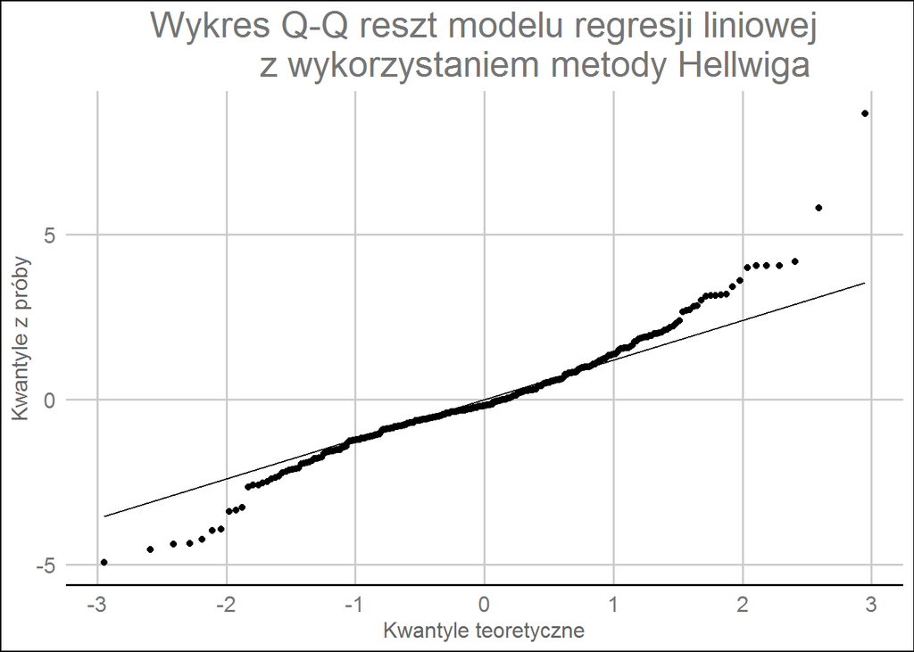

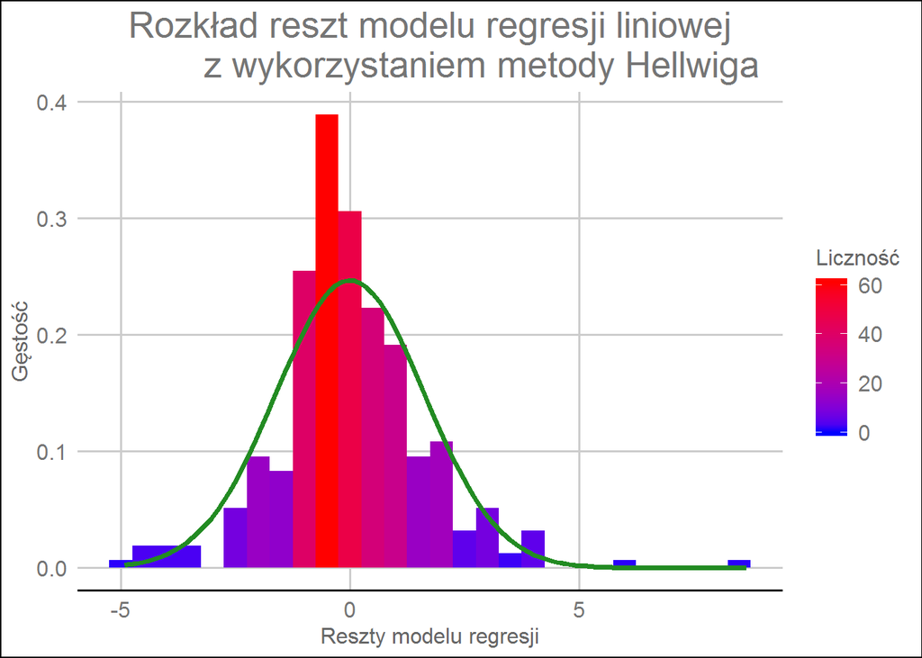

```
##
##  Jarque-Bera test for normality
##
## data:  ResztyHellwiga
## JB = 154.16, p-value < 2.2e-16
```

```
##
##  Lilliefors (Kolmogorov-Smirnov) normality test
##
## data:  ResztyHellwiga
## D = 0.077468, p-value = 0.0001051
```

```
##
##  Shapiro-Wilk normality test
##
## data:  ResztyHellwiga
## W = 0.95454, p-value = 2.715e-08
```

Zarówno wykres Q-Q, jak i histogram z dopasowaną funkcją gęstości nie dają podstaw do twierdzenia, że reszty pochodzą z rozkładu normalnego. Potwierdzają to również wyniki przeprowadzonych testów normalności. W każdym przypadku wartość p-value jest mniejsza niż 0,05. Na tej podstawie odrzucono hipotezę główną, a zatem dalsza analiza modelu jest niemożliwa.

## Regresja liniowa z wykorzystaniem metod bootstrapowych

Regresję z wykorzystaniem metod bootstrapowych wykorzystano jedynie do modelu regresji uwzględniającego wszystkie zmienne ze względu na lepsze wskaźniki dopasowania modelu tj. suma kwadratów reszt i współczynnik determinacji w porównaniu z modelem regresji, w którym zmienne dobrano za pomocą metody Hellwiga. W tej części wykorzystano dwie metody regresji bootstrapowej:

- regresja na podstawie obserwacji
- regresja na podstawie reszt

Pierwsza metoda polega na wylosowaniu (ze zwracaniem) z próby (analizowanego zbioru danych) próby bootstrapowej, czyli wartości zmiennej zależnej oraz zmiennych objaśniających dla każdej obserwacji. Na tej podstawie jest możliwe otrzymanie wektora zmiennej objaśnianej oraz macierzy zmiennych objaśniających. Do utworzonego zbioru stosowana jest metoda MNK w celu obliczenia estymatora parametrów. Po powtórzeniu całej procedury określoną ilość razy możliwe jest wyznaczenie rozkładu próby bootstrapowej.

Druga metoda polega na wylosowaniu (ze zwracaniem) reszt modelu stanowiących próbę bootstrapową. Na tej podstawie obliczane są wartości zmiennej objaśnianej. Następnie stosowana jest metoda MNK w celu otrzymania estymatora parametrów. Podobnie, jak miało to miejsce w przypadku pierwszej metody bootstrapowej, całą procedurę należy powtórzyć określoną ilość razy (w projekcie 7500), dzięki czemu możliwe jest wyznaczenie rozkładu próby bootstrapowej.

Wyniki regresji bootstrapowej dla każdej metody przedstawione zostały poniżej:

```
## BOOTSTRAP OF LINEAR MODEL  (method = rows)
##
## Original Model Fit
## ------------------
## Call:
## lm(formula = Spalanie ~ Moc + WiekSamochodu + MiejsceProdukcji +
##     ObjetoscSilnika + CzasPrzyspieszenia, data = CarsPL)
##
## Coefficients:
##        (Intercept)                 Moc       WiekSamochodu
##          -12.54233             0.05567             0.25333
##   MiejsceProdukcji     ObjetoscSilnika  CzasPrzyspieszenia
##           -0.32277             0.68452             0.30556
##
## Bootstrap SD's:
##        (Intercept)                 Moc       WiekSamochodu
##         1.63509105          0.01075415          0.02365995
##   MiejsceProdukcji     ObjetoscSilnika  CzasPrzyspieszenia
##         0.10716164          0.16887602          0.05585058
```

```
## BOOTSTRAP OF LINEAR MODEL  (method = residuals)
##
## Original Model Fit
## ------------------
## Call:
## lm(formula = Spalanie ~ Moc + WiekSamochodu + MiejsceProdukcji +
##     ObjetoscSilnika + CzasPrzyspieszenia, data = CarsPL)
##
## Coefficients:
##        (Intercept)                 Moc       WiekSamochodu
##          -12.54233             0.05567             0.25333
##   MiejsceProdukcji     ObjetoscSilnika  CzasPrzyspieszenia
##           -0.32277             0.68452             0.30556
##
## Bootstrap SD's:
##        (Intercept)                 Moc       WiekSamochodu
##        1.407198082         0.006133323         0.025619438
##   MiejsceProdukcji     ObjetoscSilnika  CzasPrzyspieszenia
##        0.137851966         0.108156650         0.041886791
```

Dla otrzymanych modeli regresji otrzymano dwie próby bootstrapowe. W ramce poniżej przedstawiono rozkład próby bootstrapowej dla każdego parametru modelu, w którym zastosowano regresję na podstawie obserwacji. Zielonymi kreskami zaznaczono 95% przedziały ufności dla każdego z parametrów.

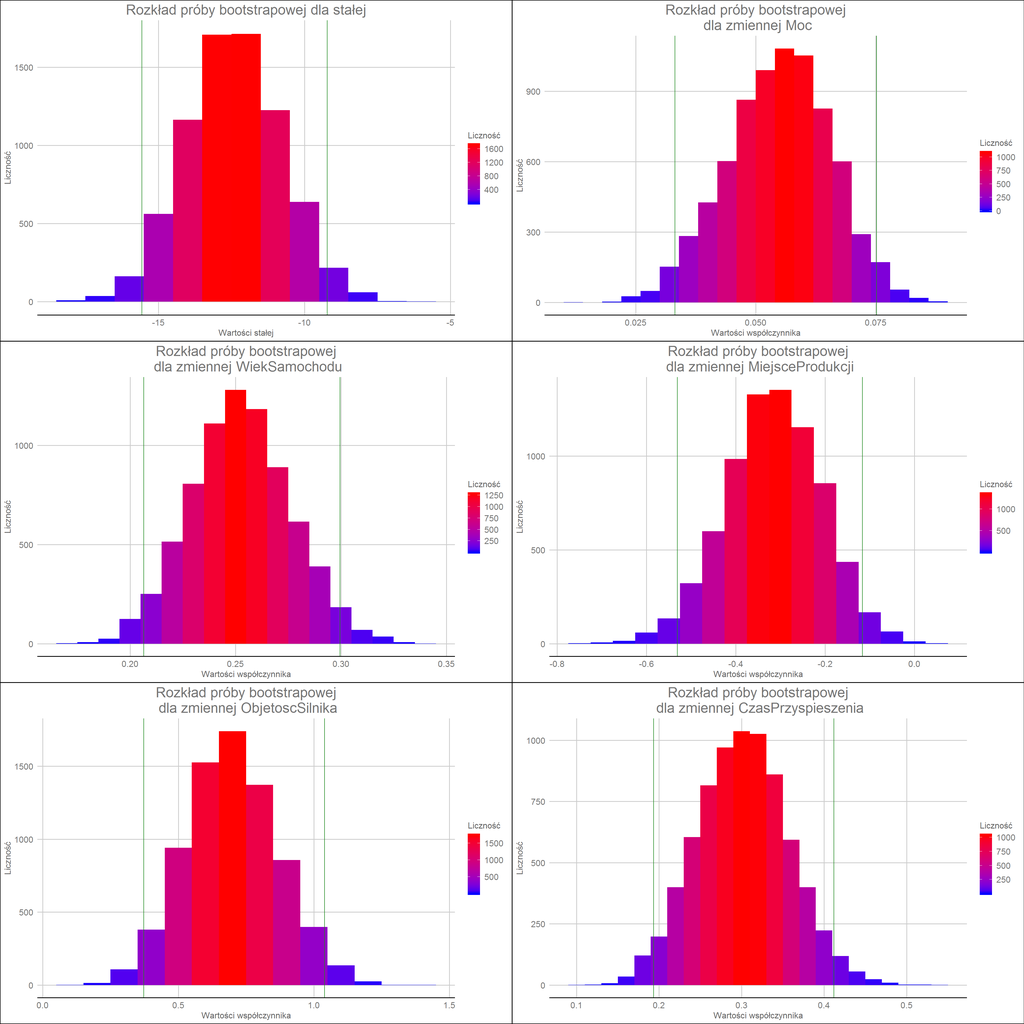

W drugiej ramce przedstawiono rozkład próby bootstrapowej dla każdego z parametrów modelu, w którym zastosowano regresję na podstawie reszt. Zielonymi kreskami zaznaczono 95% przedziały ufności dla każdego z parametrów.

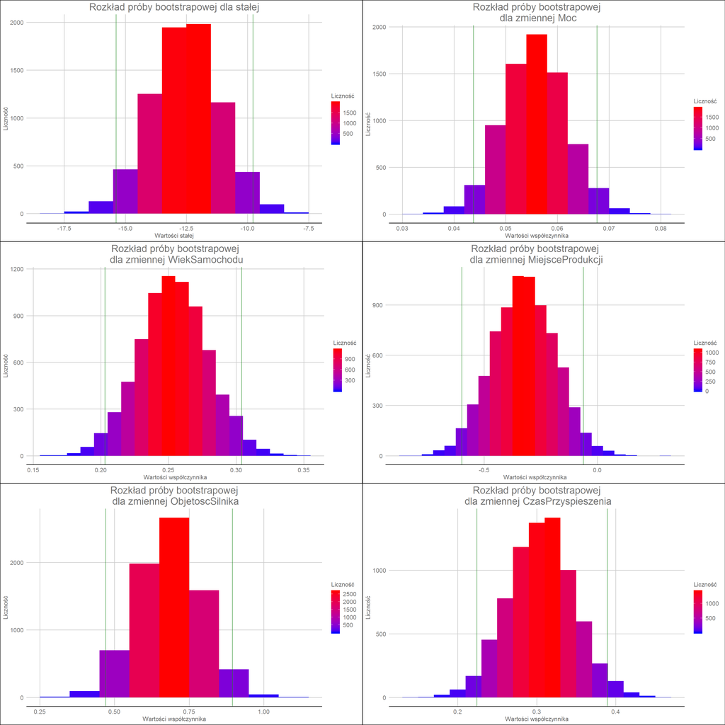

Zauważalną różnicą są niesymetryczne przedziały ufności dla parametrów modelu w metodach bootstrapowych. W przypadku regresji bootstrapowej na podstawie reszt można zauważyć, że wartości kwantyli są bardziej zbliżone do kwantyli otrzymanych dla współczynników modelu regresji liniowej zawierającego te same zmienne.

## Przekształcenia modelu

Z racji braku możliwości analizy powyższych modeli, podjęte zostały przekształcenia mające na celu przeprowadzenie pełnej diagnostyki modelu regresji. Dokonano logarytmowania wszystkich zmiennych oraz usunięcia zmiennej MiejsceProdukcji. Model ten uznano za model ostateczny. Jego parametry przedstawiono poniżej:

```
##
## Call:
## lm(formula = LogSpalanie ~ LogMoc + LogWiekSamochodu + LogObjetoscSilnika +
##     LogCzasPrzyspieszenia, data = LogCarsPL)
##
## Residuals:
##      Min       1Q   Median       3Q      Max
## -0.37991 -0.06788 -0.00182  0.07154  0.47605
##
## Coefficients:
##                       Estimate Std. Error t value Pr(>|t|)
## (Intercept)           -5.98290    0.42629 -14.035  < 2e-16 ***
## LogMoc                 0.50065    0.05093   9.830  < 2e-16 ***
## LogWiekSamochodu       1.19036    0.08501  14.003  < 2e-16 ***
## LogObjetoscSilnika     0.28360    0.02667  10.636  < 2e-16 ***
## LogCzasPrzyspieszenia  0.44476    0.05298   8.395  1.7e-15 ***
## ---
## Signif. codes:  0 '***' 0.001 '**' 0.01 '*' 0.05 '.' 0.1 ' ' 1
##
## Residual standard error: 0.117 on 309 degrees of freedom
## Multiple R-squared:  0.8833, Adjusted R-squared:  0.8818
## F-statistic: 584.8 on 4 and 309 DF,  p-value: < 2.2e-16
```

95% przedziały ufności dla parametrów i błędy szacunku przedstawiono w poniższych ramkach:

```
##                            2.5 %     97.5 %
## (Intercept)           -6.8216933 -5.1441115
## LogMoc                 0.4004331  0.6008680
## LogWiekSamochodu       1.0230864  1.3576295
## LogObjetoscSilnika     0.2311315  0.3360680
## LogCzasPrzyspieszenia  0.3405231  0.5490048
```

```
##           (Intercept)                LogMoc      LogWiekSamochodu
##            0.42628619            0.05093202            0.08500990
##    LogObjetoscSilnika LogCzasPrzyspieszenia
##            0.02666516            0.05297677
```

W tym modelu 88,33% zmienności zmniennej zależnej jest wyjaśniane przez model. Podobnie jak miało to miejsce we wcześniejszych modelach, również i ten model nie jest przeparametryzowany.

### Analiza reszt:

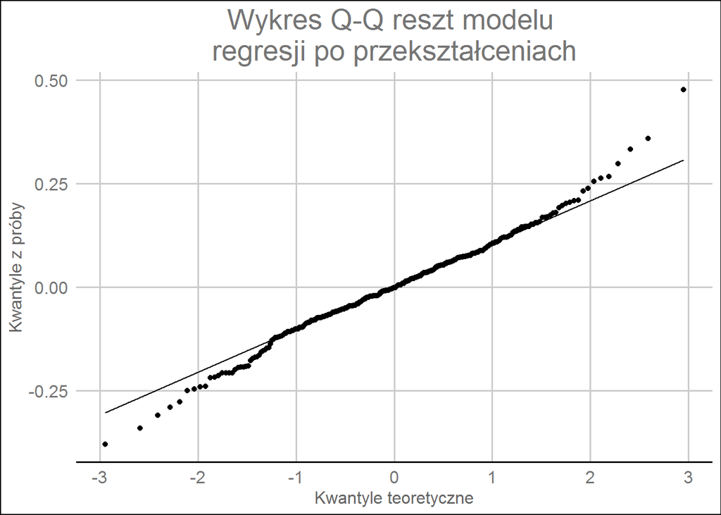

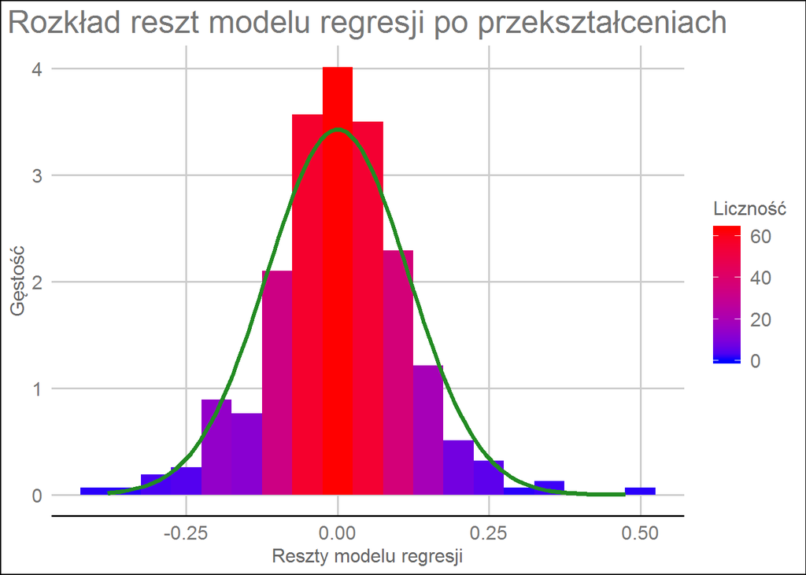

```
##
##  Jarque-Bera test for normality
##
## data:  ResztyRegresjiLLiniowej
## JB = 19.147, p-value = 0.002
```

```
##
##  Lilliefors (Kolmogorov-Smirnov) normality test
##
## data:  ResztyRegresjiLLiniowej
## D = 0.045929, p-value = 0.1102
```

```
##
##  Shapiro-Wilk normality test
##
## data:  ResztyRegresjiLLiniowej
## W = 0.9879, p-value = 0.01012
```

Histogram wraz z dopasowaną funkcją gęstości pozwalają twierdzić, że reszty pochodzą z rozkładu normalnego. Ta pożądana cecha modelu regresji została wykazana za pomocą jednego z trzech przeprowadzonych testów, a konkretnie testu Lillieforsa - wartość p-value w tym teście wynosi 0,11.

### Pozostałe testy diagnostyczne:

Testy składnika losowego pozwalają sprawdzić, czy posiadają one żądane własności, będące założeniami metody MNK. Jednym z dwóch testów składnika losowego jest test liczby serii. Służy on do zbadania, czy rozpatrywana próba jest losowa. Testowane są hipotezy:

H0: postać modelu jest dobrze dobrana

H1: postać modelu nie jest dobrze dobrana

```
##
##  Runs Test
##
## data:  ResztyRegresjiLLiniowej
## statistic = 0.33914, runs = 161, n1 = 157, n2 = 157, n = 314,
## p-value = 0.7345
## alternative hypothesis: nonrandomness
```

Wartość p-value w teście serii jest większa niż 0,05. Dzięki temu nie ma podstaw do odrzucenia hipotezy głównej. Można więc twierdzić, że postać modelu jest dobrze dobrana.

H0: składnik losowy jest homoskedastyczny

H1: składnik losowy jest heteroskedastyczny

```
##
##  studentized Breusch-Pagan test
##
## data:  LogSpalanie ~ LogMoc + LogWiekSamochodu + LogObjetoscSilnika +     LogCzasPrzyspieszenia
## BP = 3.8837, df = 4, p-value = 0.422
```

Wartość p-value w teście heteroskedastyczności wynosi 0,42. Można twierdzić, że składnik losowy modelu jest homoskedastyczny.

Test Chowa jest jednym z możliwych do zastosowania testów, które weyrfikują hipotezę o stabilności parametrów modelu. Stabilność parametrów oznacza, że nie występują ich istotne załamania. Po podziale obserwacji na dwie części i estymacji parametrów modeli pomocniczych parametry te nie powinny być istotnie rózne od parametrów modelu wyjściowego. Hipotezy w teście Chowa są następujące:

H0: parametry modelu są stabilne

H1: parametry modelu nie są stabilne

```
##
##  Chow test
##
## data:  LogSpalanie ~ LogMoc + LogWiekSamochodu + LogObjetoscSilnika +     LogCzasPrzyspieszenia
## F = 1.5355, p-value = 0.1785
```

Wartość p-value w teście Chowa wynosi 0,17. Oznacza to, że parametry modelu są stabilne i nie występują w nim istotne załamania.

Do oceny współliniowości wykorzystywany jest indeks VIF. Ma on na celu sprawdzenie, czy między dowolną parą zmiennych objaśniających występuje korelacja mniejsza niż 1. Współliniowość występuje wtedy i tylko wtedy, gdy wartość indeksu VIF jest większa od 10.

```
##                LogMoc      LogWiekSamochodu    LogObjetoscSilnika
##              6.955572              1.186072              4.705906
## LogCzasPrzyspieszenia
##              2.114158
```

Dla każdej zmiennej objaśniającej wartość indeksu VIF jest mniejsza niż 10. Oznacza to, że w rozpatrywanym modelu nie występuje zjawisko współliniowości.

Jedną z pożądanych cech modelu regresji jest jego koincydencja. Występuje ona wtedy, gdy znak parametru dla i-tej zmiennej objaśniającej jest równt znakowi współczynnika korelacji między zmienną objaśnianą a i-tą zmienną objaśniającą. Jeżeli model jest koincydentny, to wraz ze wzrostem wartości tych zmiennych objaśniających, przy których znak parametru jest dodatni, wzrastają wartości zmiennej objaśnianej. W przypadku, gdy znak parametru przy zmiennej objaśniającej jest ujemny, wartość zmiennej objaśnianej zmniejsza się wraz ze wzrostem wartości zmiennej objaśniającej.

```
##                       Współczynniki modelu Wartość współczynnika korelacji
## LogMoc                           0.5006506                       0.8484192
## LogWiekSamochodu                 1.1903580                       0.5702652
## LogObjetoscSilnika               0.2835998                       0.8665546
## LogCzasPrzyspieszenia            0.4447639                      -0.4282656
```

Dla zmiennej LogCzasPrzyspieszenia znak współczynnika nie jest równy znakowi współczynnika korelacji tej zmiennej ze zmienną objaśnianą. Oznacza to, że model nie jest koincydentny. Można wnioskować, że wraz ze wzrostem wartości wyżej wymienionej zmiennej objaśniającej wartość zmiennej zależnej nie będzie wzrastać.

## Interpretacja modelu

Przy założeniu, że wartość poszczególnych zmiennych objaśniających zmieni się o 1%, wartość zmiennej zależnej zmieni się o:

- 0,5% w przypadku zmiany wartości zmiennej LogMoc
- 1,19% w przypadku zmiany wartości zmiennej LogWiekSamochodu
- 0,28% w przypadku zmiany wartości zmiennej LogObjetoscSilnika
- 0,44% w przypadku zmiany wartości zmiennej LogCzasPrzyspieszenia

## Podsumowanie

Projekt miał na celu wyodrębnienie czynników wpływających na spalanie paliwa dla samochodów, dla których zebrały zostane dane. Badanie wykazało, że na logarytm spalania (w litrach na 100km) wpływ mają zmienne, tj.:

- logarytm mocy silnika
- logarytm wieku samochodu
- logarytm objętości silnika
- logarytm czasu przyspieszenia

Badanie zostało przeprowadzone za pomocą dwóch metod ekonometrycznych oraz dwóch metod bootstrapowych. Zastosowanie metod bootstrapowych wykazało, że tylko dla dwóch zmiennych objaśniających (MiejsceProdukcji oraz WiekSamochodu) uzyskano mniejsze błędy szacunku. Porównując zastosowane metody z ostatecznym modelem, w ostatecznym modelu najmniejsze błędy szacunku uzyskano dla stałej i zlogarytmowanej zmiennej ObjetoscSilnika.

Projekt potwierdził prawdziwość jedynie dwóch ostatnich sprawdzanych hipotez badawczych. Najwięcej samochodów w analizowanym zbiorze danych zostało wyprodukowanych w USA. Pojazdy te dodatkowo cechują się silnikami o największej objętości, a co za tym idzie, spalają najwięcej paliwa na 100 kilometrów, co zostało wykazane w ostatecznym modelu, w którym stwierdzono wpływ objętości silnika na spalanie. Z biegiem lat zaczęto produkować samochody o coraz mniejszej mocy silnika, co zostało wykazane na histogramie grupowym dla lat 1970-1982. Stwierdzono również nieprawdziwość pierwszej hipotezy mówiącej o podobnych czasach przyspieszenia. Dla większości pojazdów czas ten zawiera się w przedziale od 14 do 18 sekund, jednak występują również przypadki skrajne, dla których przyspieszenie wynosi mniej niż 10 sekund oraz więcej niż 20 sekund.